# Processing 16S rRNA gene amplicon data with DADA2.

David Barnett

Scott A. Handley

May 22, 2022

*Adapted from Ben C. Callahan benjjneb.

**DADA = Divisive Amplicon Denoising Algorithm**

# Prerequisites

**This workflow assumes that your sequencing data meets certain criteria:**

- Samples have been demultiplexed*, i.e. split into individual per-sample fastq files.
- Non-biological nucleotides have been removed, e.g. primers, adapters, linkers, etc.
- If paired-end sequencing data, the forward and reverse fastq files contain reads in matched order.

*Additional information about demultiplexing can be found on the dada2 website: https://benjjneb.github.io/dada2/index.html

# Setup

```r
library(dada2)
library(dplyr)
```

```r
library(purrr)
library(tidyr)
library(ggplot2)
```

## Find your fastq files

```r
dataPath <- here::here("data/dada2/fastqs")
list.files(dataPath)
```

```
##  [1] "806rcbc288_R1.fastq.gz" "806rcbc288_R2.fastq.gz" "806rcbc289_R1.fastq.gz"
##  [4] "806rcbc289_R2.fastq.gz" "806rcbc290_R1.fastq.gz" "806rcbc290_R2.fastq.gz"
##  [7] "806rcbc291_R1.fastq.gz" "806rcbc291_R2.fastq.gz" "806rcbc292_R1.fastq.gz"
## [10] "806rcbc292_R2.fastq.gz" "806rcbc293_R1.fastq.gz" "806rcbc293_R2.fastq.gz"
## [13] "806rcbc294_R1.fastq.gz" "806rcbc294_R2.fastq.gz" "806rcbc295_R1.fastq.gz"
## [16] "806rcbc295_R2.fastq.gz" "806rcbc296_R1.fastq.gz" "806rcbc296_R2.fastq.gz"
## [19] "806rcbc297_R1.fastq.gz" "806rcbc297_R2.fastq.gz" "806rcbc298_R1.fastq.gz"
## [22] "806rcbc298_R2.fastq.gz" "806rcbc299_R1.fastq.gz" "806rcbc299_R2.fastq.gz"
## [25] "806rcbc300_R1.fastq.gz" "806rcbc300_R2.fastq.gz" "806rcbc301_R1.fastq.gz"
## [28] "806rcbc301_R2.fastq.gz" "806rcbc302_R1.fastq.gz" "806rcbc302_R2.fastq.gz"
## [31] "806rcbc303_R1.fastq.gz" "806rcbc303_R2.fastq.gz" "filtered"
```

- Get matched lists of the forward and reverse fastq.gz files:

```r
# Forward and reverse fastq filenames have format: SAMPLENAME_R1.fastq.gz and SAMPLENAME_R2.fastq.gz
filesF <- list.files(dataPath, pattern = "_R1.fastq.gz", full.names = TRUE) %>% sort()
filesR <- list.files(dataPath, pattern = "_R2.fastq.gz", full.names = TRUE) %>% sort()
filesF[[1]]
```

```
## [1] "/Users/david/Documents/my_projects/evomics/evomics-material/data/dada2/fastqs/806rcbc288_R1.fastq.gz"
```

```r
filesR[[1]] # check the names!
```

```
## [1] "/Users/david/Documents/my_projects/evomics/evomics-material/data/dada2/fastqs/806rcbc288_R2.fastq.gz"
```

- Extract sample names, assuming filenames have format: SAMPLENAME_XXX.fastq.gz:

```r
sampleNames <- filesF %>%
  basename() %>%
  strsplit("_") %>%
  map_chr(1)
sampleNames
```

```
##  [1] "806rcbc288" "806rcbc289" "806rcbc290" "806rcbc291" "806rcbc292"
##  [6] "806rcbc293" "806rcbc294" "806rcbc295" "806rcbc296" "806rcbc297"
## [11] "806rcbc298" "806rcbc299" "806rcbc300" "806rcbc301" "806rcbc302"
## [16] "806rcbc303"
```

# Inspecting read quality

DADA2 has plotting functions so you can inspect read quality without leaving R! Let’s look at your forward and reverse read quality profiles.

We are using the 515F/806R primer set using the Illumina MiSeq paired 2x250 protocol.

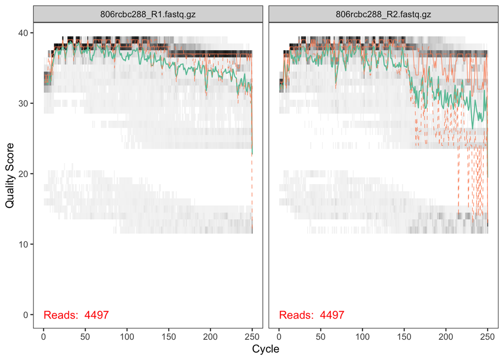

```r
# Plot the quality profile of 2 files, the forward and reverse reads of same sample
c(filesF[[1]], filesR[[1]]) %>% plotQualityProfile()
```

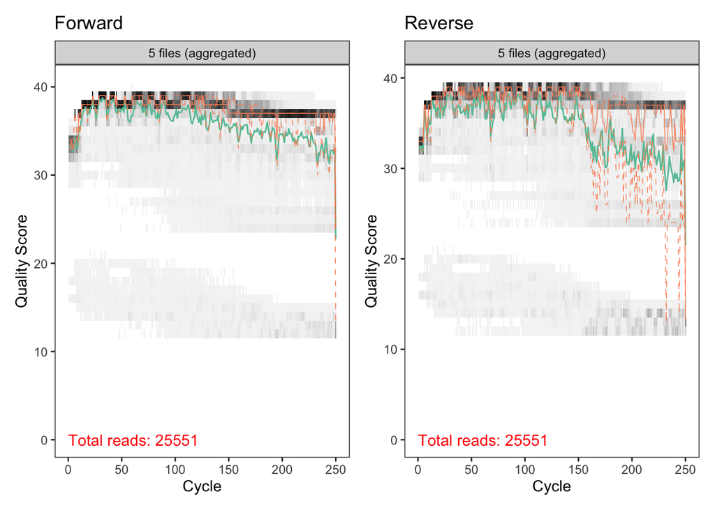

```r
# Plot the quality of forward and reverse reads, aggregating files together.
# Note: we're not plotting all 16 samples here, only because it is quite slow!
p_qual_fwd <- plotQualityProfile(filesF[1:5], aggregate = TRUE) + ggtitle("Forward")
p_qual_rev <- plotQualityProfile(filesR[1:5], aggregate = TRUE) + ggtitle("Reverse")
patchwork::wrap_plots(p_qual_fwd, p_qual_rev)
```

**Where to truncate?**

This a questions that causes more stress than necessary. Just remove obviously low quality sequence. DADA2 actually does error correction, so a bit of error is fine.

## Filter and trim

```r
# Assign filenames for the filtered fastq.gz in the filtered/ subdirectory.
filesF_filt <- file.path(dataPath, "filtered", paste0(sampleNames, "_F_filt.fastq.gz"))
filesR_filt <- file.path(dataPath, "filtered", paste0(sampleNames, "_R_filt.fastq.gz"))
```

**What values will you select for quality control?**

Pick values from the plots `p_qual_fwd` and `p_qual_rev` and set the truncLen argument like this `truncLen = c(fwd, rev)`

So if you wanted to remove 10 based from fwd and 20 bases from rev: `truncLen = c(240, 230)`

The example below is `c(240, 170)` but feel free to play with this parameter

```r
filterStats <- filterAndTrim(
  fwd = filesF, filt = filesF_filt,
  rev = filesR, filt.rev = filesR_filt,
  truncLen = c(240, 170),
  maxEE = c(2, 2), # read the help page to find out what filtering maxEE does!
  compress = TRUE, multithread = 2
)
```

## Filtering Stats

Let’s make a quick plot of the trimming results in `filterStats`

```r
# Examine the output file
head(filterStats)
```

```
##                        reads.in reads.out
## 806rcbc288_R1.fastq.gz     4497      4031
## 806rcbc289_R1.fastq.gz     5131      4635
## 806rcbc290_R1.fastq.gz     4921      4468
## 806rcbc291_R1.fastq.gz     5886      5227
## 806rcbc292_R1.fastq.gz     5116      4661
## 806rcbc293_R1.fastq.gz     5318      4735
```

```r
# Check what type of object "filterStats" is using the 'class' command
# Tip: checking the class of an object can help diagnose many common problems in R
class(filterStats)
```

```
## [1] "matrix" "array"
```

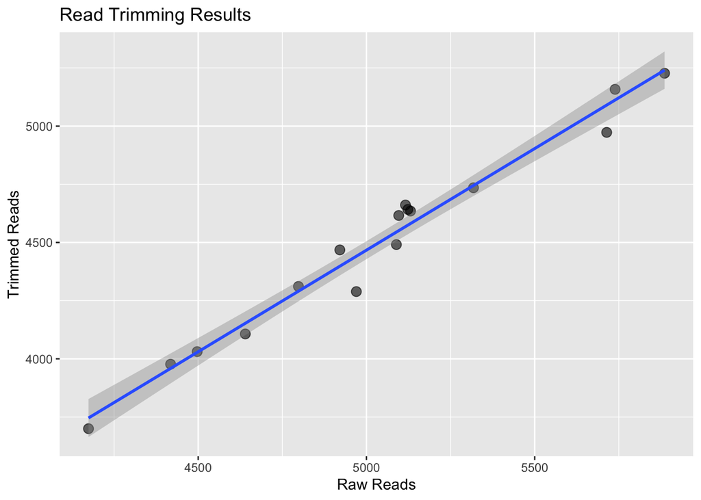

```r
# ggplot doesn't work on matrices, so you need to convert "filterStats" to a data.frame
filterStats %>%
  as.data.frame() %>%
  ggplot(aes(x = reads.in, y = reads.out)) +
  geom_point(size = 3, alpha = 0.6) +
  geom_smooth(method = "lm") + # quick linear model
  labs(x = "Raw Reads", y = "Trimmed Reads", title = "Read Trimming Results")
```

```r
# What other data can we extract from this table?
# Just some examples of how to calculate quick table statistics
filterStats %>%
  as.data.frame(row.names = 1:16) %>%
  mutate(
    sample = rownames(filterStats),
    sample = stringr::str_remove(sample, '_.+'),
    diff = reads.in - reads.out,
    percent = 100 * (reads.out / reads.in)
  )
```

```
##    reads.in reads.out     sample diff  percent
## 1      4497      4031 806rcbc288  466 89.63754
## 2      5131      4635 806rcbc289  496 90.33327
## 3      4921      4468 806rcbc290  453 90.79455
## 4      5886      5227 806rcbc291  659 88.80394
## 5      5116      4661 806rcbc292  455 91.10633
## 6      5318      4735 806rcbc293  583 89.03723
## 7      4418      3977 806rcbc294  441 90.01811
## 8      5714      4973 806rcbc295  741 87.03185
## 9      4174      3700 806rcbc296  474 88.64399
## 10     4640      4107 806rcbc297  533 88.51293
## 11     5089      4491 806rcbc298  598 88.24916
## 12     5096      4616 806rcbc299  480 90.58085
## 13     4798      4311 806rcbc300  487 89.84994
## 14     5739      5158 806rcbc301  581 89.87629
## 15     5123      4642 806rcbc302  481 90.61097
## 16     4970      4289 806rcbc303  681 86.29779
```

- What fraction of reads were kept?
- Was that fraction reasonably consistent among samples?
- Were enough reads kept to achieve your analysis goals?

**The truncation lengths are the most likely parameters you might want to revisit.**

# Learn Error Rates

The DADA2 algorithm makes use of a parametric error model (`err`) and every amplicon dataset has a different set of error rates. The `learnErrors` method learns this error model from the data, by alternating estimation of the error rates and inference of sample composition until they converge on a jointly consistent solution.

```r
# Learn the error rates for the forward reads
errF <- learnErrors(filesF_filt, multithread = 2L)
```

```
## 17285040 total bases in 72021 reads from 16 samples will be used for learning the error rates.
```

```r
# Learn the error rates for the reverse reads
errR <- learnErrors(filesR_filt, multithread = 2L)
```

```
## 12243570 total bases in 72021 reads from 16 samples will be used for learning the error rates.
```

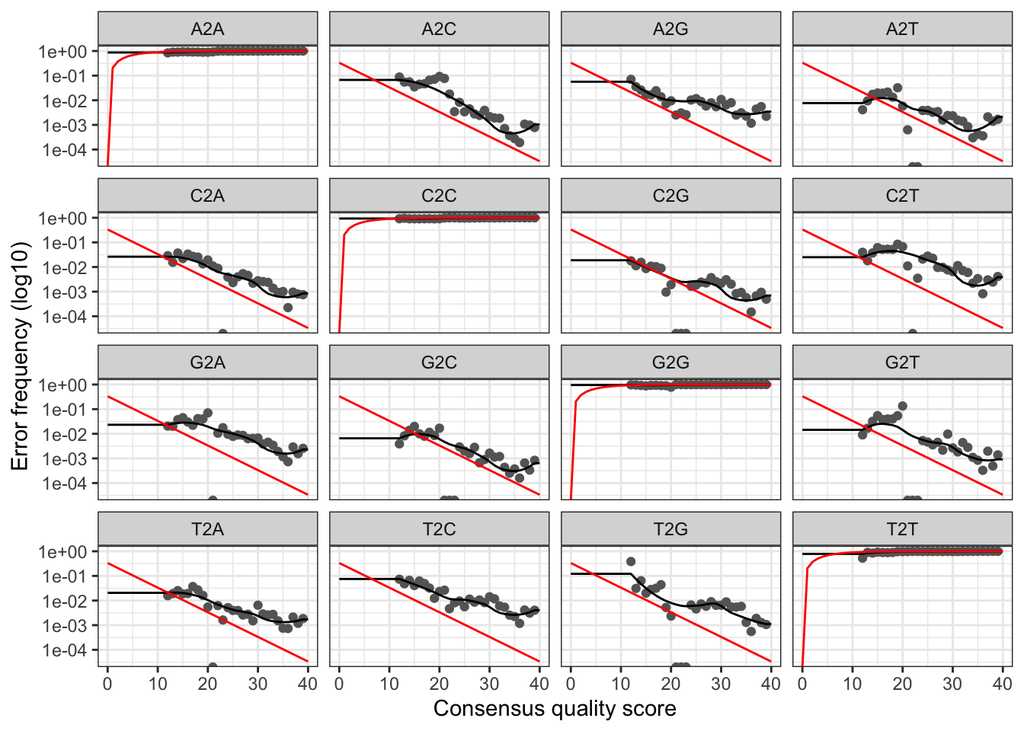

```r
# Plot individual transition and transversion error rates (for the fwd reads)
plotErrors(errF, nominalQ = TRUE)
```

- Does the model (black line) reasonably fit the observations (black points)?
- Do the error rates mostly decrease with quality score?

The goal here is good, not perfect, so don’t sweat the small stuff.

# De-replicate reads

De-replication combines all identical sequencing reads into “unique sequences” with a corresponding “abundance” equal to the number of reads with that unique sequence.

```r
# dereplicate sequences (no error correction yet!)
derep_seqsF <- derepFastq(filesF_filt)
derep_seqsR <- derepFastq(filesR_filt)

# Name the derep-class objects by the sample names
names(derep_seqsF) <- sampleNames
names(derep_seqsR) <- sampleNames

derep_seqsF[[1]]
```

```
## derep-class: R object describing dereplicated sequencing reads
## $uniques: 4031 reads in 1239 unique sequences
##   Sequence lengths: min=240, median=240, max=240
## $quals: Quality matrix dimension:  1239 240
##   Consensus quality scores: min=12, median=37, max=39
## $map: Map from reads to unique sequences:  1 3 1193 153 1 ...
```

# Denoise sequences

We are now ready to apply [the core sample inference algorithm](https://www.nature.com/articles/nmeth.3869#methods) to the dereplicated data.

```r
dada_seqsF <- dada(derep = derep_seqsF, err = errF, multithread = 2)
```

```
## Sample 1 - 4031 reads in 1239 unique sequences.
## Sample 2 - 4635 reads in 1600 unique sequences.
## Sample 3 - 4468 reads in 1619 unique sequences.
## Sample 4 - 5227 reads in 1496 unique sequences.
## Sample 5 - 4661 reads in 1268 unique sequences.
## Sample 6 - 4735 reads in 1174 unique sequences.
## Sample 7 - 3977 reads in 1369 unique sequences.
## Sample 8 - 4973 reads in 1202 unique sequences.
## Sample 9 - 3700 reads in 1052 unique sequences.
## Sample 10 - 4107 reads in 1135 unique sequences.
## Sample 11 - 4491 reads in 1570 unique sequences.
## Sample 12 - 4616 reads in 1525 unique sequences.
## Sample 13 - 4311 reads in 1469 unique sequences.
## Sample 14 - 5158 reads in 986 unique sequences.
## Sample 15 - 4642 reads in 1092 unique sequences.
## Sample 16 - 4289 reads in 1245 unique sequences.
```

```r
dada_seqsR <- dada(derep = derep_seqsR, err = errR, multithread = 2)
```

```
## Sample 1 - 4031 reads in 1379 unique sequences.
## Sample 2 - 4635 reads in 1483 unique sequences.
## Sample 3 - 4468 reads in 1491 unique sequences.
## Sample 4 - 5227 reads in 1545 unique sequences.
## Sample 5 - 4661 reads in 1391 unique sequences.
## Sample 6 - 4735 reads in 1520 unique sequences.
## Sample 7 - 3977 reads in 1299 unique sequences.
## Sample 8 - 4973 reads in 1435 unique sequences.
## Sample 9 - 3700 reads in 1228 unique sequences.
## Sample 10 - 4107 reads in 1213 unique sequences.
## Sample 11 - 4491 reads in 1506 unique sequences.
## Sample 12 - 4616 reads in 1604 unique sequences.
## Sample 13 - 4311 reads in 1448 unique sequences.
## Sample 14 - 5158 reads in 1106 unique sequences.
## Sample 15 - 4642 reads in 1336 unique sequences.
## Sample 16 - 4289 reads in 1373 unique sequences.
```

```r
# Inspecting the returned `dada-class` object (for one sample):
dada_seqsF[[1]]
```

```
## dada-class: object describing DADA2 denoising results
## 66 sequence variants were inferred from 1239 input unique sequences.
## Key parameters: OMEGA_A = 1e-40, OMEGA_C = 1e-40, BAND_SIZE = 16
```

```r
# The key thing to note here is the number of sequence variants identified in the input sequences
```

# Merge Paired Reads

```r
merged_seqs <- mergePairs(
  dadaF = dada_seqsF, derepF = derep_seqsF,
  dadaR = dada_seqsR, derepR = derep_seqsR,
  verbose = TRUE
)
```

```
## 3281 paired-reads (in 48 unique pairings) successfully merged out of 3861 (in 142 pairings) input.
```

```
## 3983 paired-reads (in 64 unique pairings) successfully merged out of 4447 (in 148 pairings) input.
```

```
## 3872 paired-reads (in 70 unique pairings) successfully merged out of 4265 (in 166 pairings) input.
```

```
## 4440 paired-reads (in 66 unique pairings) successfully merged out of 5057 (in 167 pairings) input.
```

```
## 3832 paired-reads (in 49 unique pairings) successfully merged out of 4525 (in 118 pairings) input.
```

```
## 3623 paired-reads (in 40 unique pairings) successfully merged out of 4541 (in 98 pairings) input.
```

```
## 3367 paired-reads (in 52 unique pairings) successfully merged out of 3788 (in 129 pairings) input.
```

```
## 4083 paired-reads (in 35 unique pairings) successfully merged out of 4848 (in 98 pairings) input.
```

```
## 2903 paired-reads (in 37 unique pairings) successfully merged out of 3554 (in 110 pairings) input.
```

```
## 3339 paired-reads (in 43 unique pairings) successfully merged out of 3937 (in 118 pairings) input.
```

```
## 3884 paired-reads (in 62 unique pairings) successfully merged out of 4307 (in 147 pairings) input.
```

```
## 3676 paired-reads (in 65 unique pairings) successfully merged out of 4384 (in 142 pairings) input.
```

```
## 3616 paired-reads (in 64 unique pairings) successfully merged out of 4102 (in 141 pairings) input.
```

```
## 4338 paired-reads (in 36 unique pairings) successfully merged out of 5054 (in 79 pairings) input.
```

```
## 3521 paired-reads (in 38 unique pairings) successfully merged out of 4492 (in 82 pairings) input.
```

```
## 3375 paired-reads (in 56 unique pairings) successfully merged out of 4133 (in 107 pairings) input.
```

```r
merged_seqs$`806rcbc288` %>% glimpse() # have a look at the data for one sample
```

```
## Rows: 48
## Columns: 9
## $ sequence  <chr> "TACGGAGGATGCGAGCGTTATCCGGATTTATTGGGTTTAAAGGGTGCGTAGGCGGGATG…
## $ abundance <int> 725, 411, 359, 352, 175, 163, 91, 80, 64, 58, 50, 47, 46, 45…
## $ forward   <int> 1, 2, 3, 4, 24, 6, 7, 29, 8, 9, 31, 58, 17, 10, 34, 13, 41, …
## $ reverse   <int> 1, 3, 2, 4, 24, 5, 6, 22, 7, 8, 23, 43, 9, 10, 25, 12, 2, 36…
## $ nmatch    <int> 158, 158, 157, 157, 158, 158, 157, 158, 157, 157, 158, 158, …
## $ nmismatch <int> 0, 0, 0, 0, 0, 0, 0, 0, 0, 0, 0, 0, 0, 0, 0, 0, 0, 0, 0, 0, …
## $ nindel    <int> 0, 0, 0, 0, 0, 0, 0, 0, 0, 0, 0, 0, 0, 0, 0, 0, 0, 0, 0, 0, …
## $ prefer    <dbl> 1, 1, 2, 1, 1, 2, 2, 2, 2, 2, 1, 1, 2, 2, 2, 2, 2, 1, 1, 1, …
## $ accept    <lgl> TRUE, TRUE, TRUE, TRUE, TRUE, TRUE, TRUE, TRUE, TRUE, TRUE, …
```

It is debatable if merging paired reads adds anything to the analysis for this primer set. Since R1 (fwd) and R2 (rev) sequence an overlapping region of the 16S rRNA gene, just analyzing R1 is essentially the same as analyzing merged R1-R2.

Other primer sets of genes (ITS, 18S, etc.) might benefit from merging.

**Most reads should pass the merging step! If that isn’t the case, are you sure your truncated reads still overlap sufficiently?**

# Construct Sequence Table (ASV Table)

```r
seqtab <- makeSequenceTable(merged_seqs)
dim(seqtab)
```

```
## [1]  16 196
```

```r
class(seqtab)
```

```
## [1] "matrix" "array"
```

```r
rownames(seqtab)
```

```
##  [1] "806rcbc288" "806rcbc289" "806rcbc290" "806rcbc291" "806rcbc292"
##  [6] "806rcbc293" "806rcbc294" "806rcbc295" "806rcbc296" "806rcbc297"
## [11] "806rcbc298" "806rcbc299" "806rcbc300" "806rcbc301" "806rcbc302"
## [16] "806rcbc303"
```

```r
colnames(seqtab)[1:3]
```

```
## [1] "TACGGAGGATGCGAGCGTTATCCGGATTTATTGGGTTTAAAGGGTGCGTAGGCGGGATGC…"
## [2] "TACGGAGGATTCAAGCGTTATCCGGATTTATTGGGTTTAAAGGGTGCGTAGGCGGTCGGA…"
## [3] "TACAGAGGTCTCAAGCGTTGTTCGGAATCACTGGGCGTAAAGCGTGCGTAGGCTGTTTCG…"
```

```r
seqtab[1:10]
```

```
##  [1]  725  771  501  694  883 1251  581 1399  652  910
```

The sequence table is a `matrix` with rows corresponding to (and named by) the samples, and columns corresponding to (and named by) the sequence variants.

# Remove chimeras

Chimeric sequences are identified if they can be exactly reconstructed by combining a left-segment and a right-segment from two more abundant “parent” sequences.

```r
seqtab_nochim <- removeBimeraDenovo(seqtab, method = "consensus", verbose = TRUE)
```

[output not shown]

```r
# Calculate % of reads that pass chimera filtering
100 * (sum(seqtab_nochim) / sum(seqtab))
```

```
## [1] 94.35172
```

# Track reads through the pipeline

```r
# This is some custom code to pull out important values from the dada2 workflow
# Don't worry too much about the code at this point, just focus on the results table
getN <- function(x) sum(getUniques(x))

readTrackingDf <- tibble(
  sample = sampleNames,
  input = filterStats[, "reads.in"], filtered = filterStats[, "reads.out"],
  denoisedF = map_dbl(dada_seqsF, getN), denoisedR = map_dbl(dada_seqsR, getN),
  merged = map_dbl(merged_seqs, getN), nonChimeric = rowSums(seqtab_nochim)
)

readTrackingDf
```

```
## # A tibble: 16 × 7
##    sample     input filtered denoisedF denoisedR merged nonChimeric
##    <chr>      <dbl>    <dbl>     <dbl>     <dbl>  <dbl>       <dbl>
##  1 806rcbc288  4497     4031      3903      3929   3281        2952
##  2 806rcbc289  5131     4635      4477      4555   3983        3762
##  3 806rcbc290  4921     4468      4310      4364   3872        3680
##  4 806rcbc291  5886     5227      5091      5140   4440        3877
##  5 806rcbc292  5116     4661      4542      4597   3832        3501
##  6 806rcbc293  5318     4735      4565      4654   3623        3360
##  7 806rcbc294  4418     3977      3834      3891   3367        3237
##  8 806rcbc295  5714     4973      4884      4914   4083        3873
##  9 806rcbc296  4174     3700      3591      3633   2903        2740
## 10 806rcbc297  4640     4107      3995      4011   3339        3186
## 11 806rcbc298  5089     4491      4341      4413   3884        3807
## 12 806rcbc299  5096     4616      4412      4536   3676        3540
## 13 806rcbc300  4798     4311      4127      4214   3616        3460
## 14 806rcbc301  5739     5158      5078      5112   4338        4213
## 15 806rcbc302  5123     4642      4530      4567   3521        3392
## 16 806rcbc303  4970     4289      4163      4210   3375        3213
```

```r
# ggplot2 (and all of tidyverse) works really well with 'long' form data
# Let's convert to long form so we can make a line plot of each stage
readTrackingDf_long <- readTrackingDf %>%
  mutate(max = input) %>%
  pivot_longer(
    cols = !c(sample, max), # Pivot everything other than those 2 column to 'long' format
    values_to = "Number", # Column name for values
    names_to = "Stage" # Column name for stages
  ) %>%
  mutate(Proportion = Number/max) %>%
  mutate(sample = forcats::fct_reorder(sample, -Number)) %>%
  mutate(Stage = forcats::fct_reorder(Stage, -Number))
```

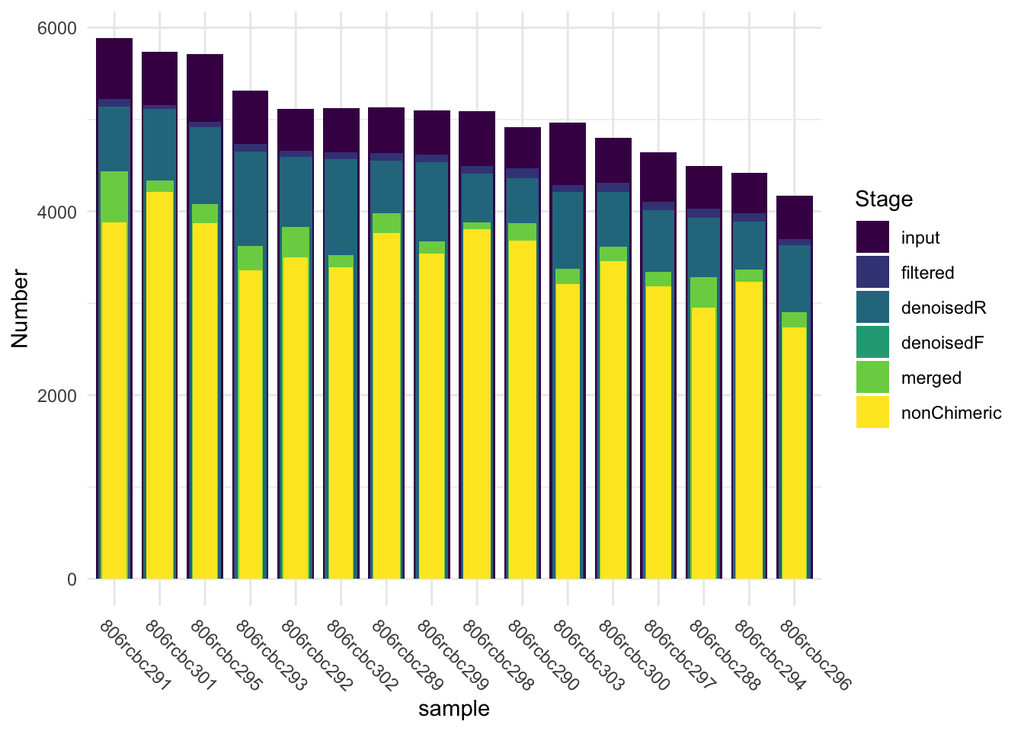

```r
# Now we can plot the number of reads per each stage
readTrackingDf_long %>%
  ggplot(aes(x = sample, y = Number, fill = Stage, group = Stage)) +
  # geom_col(position = position_dodge(preserve = 'total')) +
  geom_col(position = position_identity(), width = readTrackingDf_long$Proportion * 0.8) +
  theme_minimal() +
  theme(axis.text.x = element_text(angle = -45, hjust = 0.1)) +
  scale_fill_viridis_d()
```

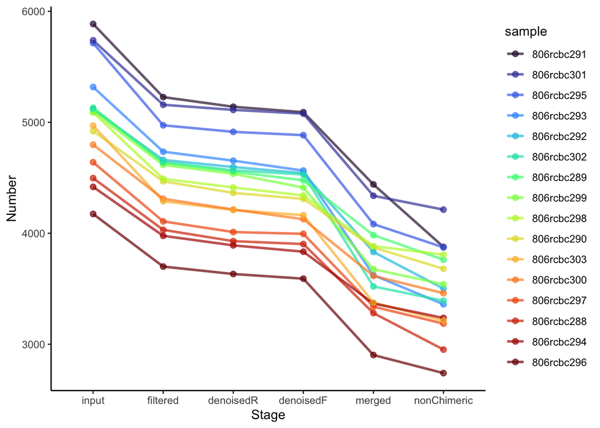

```r
readTrackingDf_long %>%
ggplot(aes(x = Stage, y = Number, colour = sample)) +
  geom_line(aes(colour = sample, group = sample), alpha = 0.7, size = 1) +
  geom_point(alpha = 0.7, size = 2) +
  scale_colour_viridis_d(option = 'turbo') +
  theme_classic()
```

Looks good! We kept the majority of our raw reads, and there is no over-large drop associated with any single step.

- If a majority of reads failed to merge, you may need to revisit `truncLen` to ensure overlap.
- If a majority of reads were removed as chimeric, you may still have primers in your sequences.

# Assign Taxonomy

The `assignTaxonomy` function takes as input a set of sequences to be classified, and a training set of reference sequences with known taxonomy, and outputs taxonomic assignments with at least `minBoot` bootstrap confidence.

This process can be slow, so we have precomputed this. The command you would actually run is commented out in the following chunk. Do not run this, but DO run `readRDS` instead to load the precomputed taxonomic assignment file.

```r
### Commented out for workshop-time-limit friendliness
### taxa <- assignTaxonomy(seqtab_nochim, "../data/rdp_train_set_16.fa.gz", multithread=2)
taxa <- readRDS(file.path(dataPath, "..", "taxa.rds"))
class(taxa)
```

```
## [1] "matrix" "array"
```

For more discussion of taxonomic assignment with DADA2, see https://benjjneb.github.io/dada2/assign.html

# Handoff to Phyloseq

```r
library("phyloseq")
ps <- phyloseq(
  otu_table(seqtab_nochim, taxa_are_rows = FALSE), tax_table(taxa)
)
ps
```

```
## phyloseq-class experiment-level object
## otu_table()   OTU Table:         [ 149 taxa and 16 samples ]
## tax_table()   Taxonomy Table:    [ 149 taxa by 6 taxonomic ranks ]
```

```r
# Some sanity checks
nsamples(ps)
```

```
## [1] 16
```

```r
get_taxa_unique(ps, "Family")
```

```
##  [1] "Porphyromonadaceae"                "Rikenellaceae"
##  [3] "Verrucomicrobiaceae"               "Lachnospiraceae"
##  [5] "Erysipelotrichaceae"               "Ruminococcaceae"
##  [7] "Lactobacillaceae"                  NA
##  [9] "Anaeroplasmataceae"                "Clostridiaceae_1"
## [11] "Peptostreptococcaceae"             "Staphylococcaceae"
## [13] "Bifidobacteriaceae"                "Clostridiales_Incertae_Sedis_XIII"
## [15] "Coriobacteriaceae"
```

# Extras

## DADA2 options:

### Big data:

The tutorial dataset is small enough to easily load into memory. If your dataset exceeds available RAM, it is preferable to process samples one-by-one in a streaming fashion: see the DADA2 Workflow on Big Data for an example.

### Pooling

Pooling can [increase sensitivity to rare per-sample variants](https://benjjneb.github.io/dada2/pool.html#pooling-for-sample-inference). Pseudo-pooling [approximates pooling in linear time](https://benjjneb.github.io/dada2/pseudo.html#pseudo-pooling).

*The adventurous can see `?setDadaOpt` for more algorithmic parameters.*

## Phylogenetic tree construction

Instructions for constructing a phylogenetic tree for our ASVs can be found below. This process is reproduced from [Callahan 2016](https://f1000research.com/articles/5-1492/v2)

Phylogenetic relatedness is commonly used to inform downstream analyses, especially the calculation of phylogeny-aware distances between microbial communities. The DADA2 sequence inference method is reference-free, so we must construct the phylogenetic tree relating the inferred sequence variants de novo. We begin by performing a multiple-alignment using the DECIPHER R package.

```r
seqs <- getSequences(seqtab_nochim)
names(seqs) <- seqs # This propagates to the tip labels of the tree
alignment <- AlignSeqs(DNAStringSet(seqs), anchor = NA)
```

The `phangorn` R package is then used to construct a phylogenetic tree. Here we first construct a neighbor-joining tree, and then fit a GTR+G+I (Generalized time-reversible with Gamma rate variation) maximum likelihood tree using the neighbor-joining tree as a starting point.

```r
phang.align <- phyDat(as(alignment, "matrix"), type = "DNA")
dm <- dist.ml(phang.align)
treeNJ <- NJ(dm) # Note, tip order != sequence order
fit <- pml(treeNJ, data = phang.align)
```

```r
fitGTR <- update(fit, k = 4, inv = 0.2)
fitGTR <- optim.pml(fitGTR,
  model = "GTR", optInv = TRUE, optGamma = TRUE,
  rearrangement = "stochastic", control = pml.control(trace = 0)
)
phy_tree(ps) <- fitGTR$tree
```